# mathPOTW2

[figure not shown]

my first inclination was to wall along each vertex of the cube and count the possibilities

vertex 0 [0,0,0]; we have 3 different options

the second vertex;

[1,0,0] v [0,1,0] v [0,0,1] we would have 2 becaus we cant go back to the previous state [0,0,0]

(side note); we could compute this using a NFA where S = {0,1}; or a boolean epso = {{permutations of a 3d boolean vector , ex; [0,0,0]...[1,1,1]}} we then would have to compute a transition function that takes the state and transforms it to a valid state and the ending state would be [1,1,1]

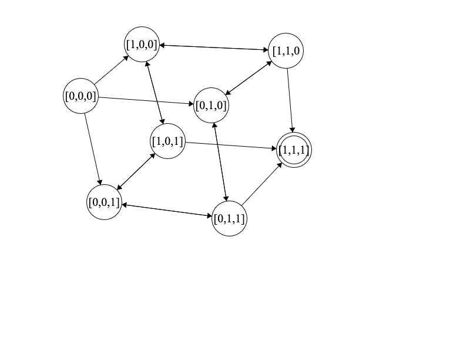

this is a good visual but there are some issues with this(we would run into the halting problem becaus we would loop for ever) we lose some of the information about the state in the NFA. becaus there are different states for each branch of the automata. so the real automata would look like more of a tree with repeating nodes

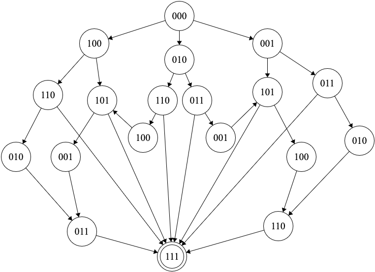

we can see that we have some symmetry of this tree we can just look at this graph and tell that we have at least have 8 paths but that is not the answer we can brute force the answer of this using a simple graph search or using DFA that we make using the NFA and computing all matches posable. we can also represent this with binary number of size 2^3

```python
## we can use a tree traversal to compute all paths and print all of them out
class path:
    def __init__(self):
        self.size = 0
        self.pathway = [0b000]## we start with 000

    def clone(self):
        P = path()
        P.size =self.size
        P.pathway = self.pathway.copy()
        return P

    def last(self):
        return self.pathway[self.size]

    def append(self,vec):
        self.size += 1
        self.pathway.append(vec)

    def __str__(self):
        binary_path = [bin(x)[2:].zfill(3) for x in self.pathway]  # Convert to binary
        return str(binary_path)  # Return the binary representation

    def isValidMove(self, move):
        return not(move in self.pathway)


def find(path):
    global count

    if path.last() == 7:
        count += 1
        print(f"Path {count}: {path}") # Print the complete path only when it reaches 7
        return # stop further exploration once we reach 7
    else:
        for move_bit in [0b001, 0b010, 0b100]: # Iterate over the move bits
            new_move = path.last() ^ move_bit
            if path.isValidMove(new_move):
                P = path.clone()
                P.append(new_move)
                find(P)

count =0
def main():
    print("start___finding pathways")
    P = path()
    find(P)

if __name__=="__main__":
    main()
```

```
start___finding pathways
Path 1: ['000', '001', '011', '010', '110', '111']
Path 2: ['000', '001', '011', '010', '110', '100', '101', '111']
Path 3: ['000', '001', '011', '111']
Path 4: ['000', '001', '101', '100', '110', '111']
Path 5: ['000', '001', '101', '100', '110', '010', '011', '111']
Path 6: ['000', '001', '101', '111']
Path 7: ['000', '010', '011', '001', '101', '100', '110', '111']
Path 8: ['000', '010', '011', '001', '101', '111']
Path 9: ['000', '010', '011', '111']
Path 10: ['000', '010', '110', '111']
Path 11: ['000', '010', '110', '100', '101', '111']
Path 12: ['000', '010', '110', '100', '101', '001', '011', '111']
Path 13: ['000', '100', '101', '111']
Path 14: ['000', '100', '101', '001', '011', '010', '110', '111']
Path 15: ['000', '100', '101', '001', '011', '111']
Path 16: ['000', '100', '110', '111']
Path 17: ['000', '100', '110', '010', '011', '001', '101', '111']
Path 18: ['000', '100', '110', '010', '011', '111']
```

```
so we know by doing a tree traversal of the graph we have 18 paths but we should thing of this in a more mathematical way

if we start at node 1 [0,0,0] we have 3 options
so our possibility become 3 * P where P is the rest of the expression

then at the second depth we have 2 valid moves so
3 * 2 * P

then we are at something like [1,1,0]
we still have 2 options for any of the nodes in this layer so
3 * 2 * 2 * P

this is where it gets tricky
2 of the nodes at this depth lead back to have 2 options [1,0,0] and [0,0,1] but the other only have 1 option
so we would only half to add the remaining paths to the current number witch is 4

we then get 3 * 2 * 2 + 4 = 16

this means that my code was incorrect or my math was
 looking trough the output if my math was correct then there should be 2 invalid or 2 correct paths i didn't account for

after renewing the paths it looks like there are 2 paths that didn't account fore
 Path 2: ['000', '001', '011', '010', '110', '100', '101', '111']
 Path 17: ['000', '100', '110', '010', '011', '001', '101', '111']


so the 3 * 2 * 2 + 6  = 18

i wish there was a more compleat way of finding the answer one that is in pure math
```